# GLMM evaluation

Hao Lu

June 15, 2019

# Set up analysis environment

```r
library(readxl)
library(magrittr)
library(lme4)
library(car)
library(tidyverse)
library(lsmeans)
library(afex)
```

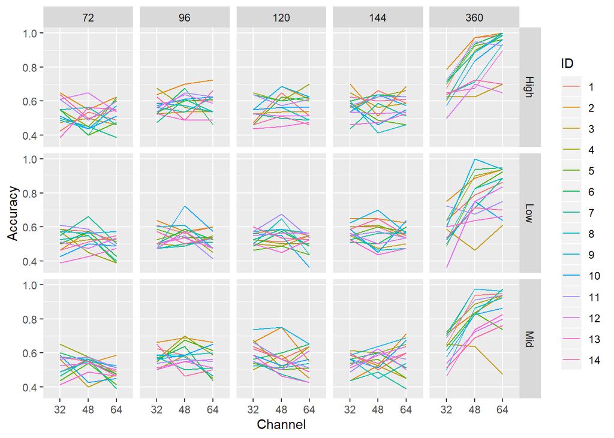

```r
library(lsmeans)

CI_data <- read_excel("M:/Lab_Shared/HaoLu/GLMM_Anoo/GLMM_stats_dataset.xlsx")

# Set categorical data as factors:
CI_data$ID %<>% as.factor()
CI_data$Slope %<>% as.factor()
CI_data$Position %<>% as.factor()
CI_data$Channel %<>% as.factor()

# Convert accuracy to success and failure counts
CI_data$Accuracy = CI_data$Accuracy/100
CI_data$Response = cbind(CI_data$Accuracy * 80, (1 - CI_data$Accuracy) *
    80)

# default contrast setting does not satisfy type-III anova
# assumption so it was reseted
options(contrasts = c("contr.sum", "contr.poly"))

# Plot data
ggplot(CI_data, aes(x = Channel, y = Accuracy, group = ID, color = ID)) +
    geom_line() + facet_grid(Position ~ Slope)
```

Each row shows accuracy of a Condition and each column shows accuracy of a Slope.

According to the plot above and results of repeated measure ANOVA, dataset was split into two subsets before fitting model (Slope = 360 and other slope).

```r
# Split data into two groups for experiment 1 and experiment
# 2
CI_data_exp1 = CI_data[CI_data$Slope == 360, ]
CI_data_exp2 = CI_data[CI_data$Slope != 360, ]

# Drop the unused slope level in data of experiment 2 (slope
# = 360) This crucial because afex package will freak out
# without this line of code
CI_data_exp2$Slope = droplevels(CI_data_exp2$Slope)
```

Now all data is preprocessed and we are starting modeling

# Experiment 1 data analysis

## Fitting models

The reviewer suggested to fit generalized linear mixed model (GLMM) using logit link function with lme4 R package.

Considering sample size and our general assumption, the global model we can fit includes all factors as main effects and a random intercept for each subject. I have tried more complicated random factor structure like adding random effect of position but the model failed to converge. So the model below is the best we can do here.

```r
m.1.full = glmer(Response ~ Position * Channel + (1 | ID), data = CI_data_exp1,
    family = binomial("logit"))
summary(m.1.full)
```

```
## Generalized linear mixed model fit by maximum likelihood (Laplace
##   Approximation) [glmerMod]
##  Family: binomial  ( logit )
## Formula: Response ~ Position * Channel + (1 | ID)
##    Data: CI_data_exp1
##
##      AIC      BIC   logLik deviance df.resid
##   1023.2   1051.5   -501.6   1003.2      116
##
## Scaled residuals:
##     Min      1Q  Median      3Q     Max
## -5.2439 -1.0769  0.2973  1.4184  4.4469
##
## Random effects:
##  Groups Name        Variance Std.Dev.
##  ID     (Intercept) 0.2534   0.5034
## Number of obs: 126, groups:  ID, 14
##
## Fixed effects:
##                      Estimate Std. Error z value Pr(>|z|)
## (Intercept)         1.3500804  0.1372254   9.838  < 2e-16 ***
## Position1           0.2404981  0.0386572   6.221 4.93e-10 ***
## Position2          -0.2634131  0.0355974  -7.400 1.36e-13 ***
## Channel1           -0.8442228  0.0339168 -24.891  < 2e-16 ***
## Channel2            0.2229180  0.0372132   5.990 2.09e-09 ***
## Position1:Channel1 -0.0750330  0.0490304  -1.530   0.1259
## Position2:Channel1  0.0879407  0.0463107   1.899   0.0576 .
## Position1:Channel2 -0.0957515  0.0542239  -1.766   0.0774 .
## Position2:Channel2  0.0007666  0.0505711   0.015   0.9879
## ---
## Signif. codes:  0 '***' 0.001 '**' 0.01 '*' 0.05 '.' 0.1 ' ' 1
##
## Correlation of Fixed Effects:
##             (Intr) Postn1 Postn2 Chnnl1 Chnnl2 Ps1:C1 Ps2:C1 Ps1:C2
## Position1    0.023
## Position2   -0.024 -0.507
## Channel1    -0.057 -0.080  0.081
## Channel2     0.003 -0.042  0.007 -0.364
## Pstn1:Chnn1 -0.015 -0.308  0.142  0.081  0.025
## Pstn2:Chnn1  0.015  0.139 -0.235 -0.080  0.003 -0.504
## Pstn1:Chnn2 -0.009 -0.023  0.023  0.026  0.086 -0.325  0.161
## Pstn2:Chnn2  0.001  0.023  0.014  0.003 -0.111  0.163 -0.386 -0.492
```

There should also be correlation of random factors like what was described in Jaeger’s paper but we only have one random intercept so it was omitted.

## testing fixed effects

The following results are output from Henrik Singmann’s afex::mix and it was copy and pasted because it usually takes hours to run bootstrap simulation, simulation was used here)

```r
# below is the code used to generate PB result exp1.mix =
# mixed(Response ~ Slope*Position*Channel+(1|ID),
# data=CI_data_exp2,
# family=binomial,method='PB',cl=cl,all_fit=FALSE,args_test=list(cl=cl,
# nsim=1000))

# To save compling time, we simply read results saved before
exp1.mix = readRDS("M:/Lab_Shared/HaoLu/GLMM_Anoo/Exp1_PB.rds")

nice(exp1.mix)
```

```
## Mixed Model Anova Table (Type 3 tests, PB-method)
##
## Model: Response ~ Position * Channel + (1 | ID)
## Data: CI_data_exp1
##             Effect df     Chisq p.value
## 1         Position  2  63.49 **    .001
## 2          Channel  2 659.33 **    .002
## 3 Position:Channel  4   10.23 *     .04
## ---
## Signif. codes:  0 '***' 0.001 '**' 0.01 '*' 0.05 '+' 0.1 ' ' 1
```

Results of PB are pinted above.

Notice that although chi squre values are shown. These p-values are NOT derived from chi squares, so these chi square values should NOT be reported with p-values.

It can be seen that all effects are significant, so we are going to keep the global model as minimal adequate model for experiment 1 and it will be used for further analysis.

## Comparison with chance level (50%)

Then we want to test whether performance is significantly above chance level.

Due to significant interaction between position and channel. We will have to specify level of both factors in comparison (e.g. Position = High, and Channel = 32 is significantly above chance). Also because we want to test whether performance is significantly above chance level, so all hypothesis tests are ont-tailed.

```r
m.1.means = lsmeans(m.1.full, pairwise ~ Channel:Position)
summary(m.1.means, null = 0, infer = c(TRUE, TRUE), adjust = "bon",
    type = "response", side = "1")$lsmeans
```

```
##  Channel Position  prob     SE  df asymp.LCL asymp.UCL z.ratio p.value
##  32      High     0.662 0.0334 Inf     0.573         1  4.497  <.0001
##  48      High     0.848 0.0204 Inf     0.789         1 10.879  <.0001
##  64      High     0.915 0.0132 Inf     0.875         1 13.984  <.0001
##  32      Low      0.582 0.0361 Inf     0.488         1  2.228  0.1164
##  48      Low      0.788 0.0257 Inf     0.715         1  8.546  <.0001
##  64      Low      0.835 0.0216 Inf     0.772         1 10.339  <.0001
##  32      Mid      0.626 0.0348 Inf     0.534         1  3.468  0.0024
##  48      Mid      0.844 0.0207 Inf     0.784         1 10.733  <.0001
##  64      Mid      0.871 0.0180 Inf     0.818         1 11.892  <.0001
##
## Confidence level used: 0.95
## Conf-level adjustment: bonferroni method for 9 estimates
## Intervals are back-transformed from the logit scale
## P value adjustment: bonferroni method for 9 tests
## P values are right-tailed
## Tests are performed on the logit scale
```

Results showed that only Low/32 channel ondition is not significantly above 0

Notice that all tests are performed on the logic scale which means we compare the logit transformed data with 0 (chance level in logit scale). The “prob” and 95% confidence interval of prob are transformed from logit result.

## Pairwise comparison

```r
m.1.pairs = lsmeans(m.1.full, pairwise ~ Channel | Position)
summary(m.1.pairs, type = "response")$contrasts
```

```
## Position = High:
##  contrast odds.ratio     SE  df z.ratio p.value
##  32 / 48       0.351 0.0368 Inf  -9.997 <.0001
##  32 / 64       0.181 0.0222 Inf -13.953 <.0001
##  48 / 64       0.514 0.0682 Inf  -5.014 <.0001
##
## Position = Low:
##  contrast odds.ratio     SE  df z.ratio p.value
##  32 / 48       0.375 0.0361 Inf -10.175 <.0001
##  32 / 64       0.276 0.0280 Inf -12.705 <.0001
##  48 / 64       0.734 0.0795 Inf  -2.852 0.0121
##
## Position = Mid:
##  contrast odds.ratio     SE  df z.ratio p.value
##  32 / 48       0.309 0.0319 Inf -11.362 <.0001
##  32 / 64       0.247 0.0268 Inf -12.892 <.0001
##  48 / 64       0.801 0.0959 Inf  -1.849 0.1538
##
## P value adjustment: tukey method for comparing a family of 3 estimates
## Tests are performed on the log odds ratio scale
```

Notice that p-values are adjusted for 3 pairs of comparisons within a target position.

# Experiment 2 data analysis

## Fitting full models

Similarly we start from a full model

```r
m.2.full = glmer(Response ~ Slope * Position * Channel + (1 |
    ID), data = CI_data_exp2, family = binomial("logit"))
summary(m.2.full)
```

```
## Generalized linear mixed model fit by maximum likelihood (Laplace
##   Approximation) [glmerMod]
##  Family: binomial  ( logit )
## Formula: Response ~ Slope * Position * Channel + (1 | ID)
##    Data: CI_data_exp2
##
##      AIC      BIC   logLik deviance df.resid
##   3072.3   3228.5  -1499.2   2998.3      467
##
## Scaled residuals:
##      Min       1Q   Median       3Q      Max
## -2.90769 -0.78837  0.05831  0.70497  3.06854
##
## Random effects:
##  Groups Name        Variance Std.Dev.
##  ID     (Intercept) 0.01409  0.1187
## Number of obs: 504, groups:  ID, 14
##
## Fixed effects:
##                             Estimate Std. Error z value Pr(>|z|)
## (Intercept)                0.1912942  0.0332801   5.748 9.03e-09 ***
## Slope1                    -0.1322487  0.0173349  -7.629 2.37e-14 ***
## Slope2                     0.0594299  0.0174211   3.411 0.000646 ***
## Slope3                     0.0203054  0.0173971   1.167 0.243141
## Position1                  0.0369001  0.0142097   2.597 0.009409 **
## Position2                 -0.0536921  0.0141802  -3.786 0.000153 ***
## Channel1                   0.0114922  0.0141986   0.809 0.418290
## Channel2                   0.0302215  0.0142066   2.127 0.033397 *
## Slope1:Position1          -0.0109661  0.0245226  -0.447 0.654741
## Slope2:Position1           0.0378901  0.0246794   1.535 0.124712
## Slope3:Position1          -0.0166868  0.0246118  -0.678 0.497771
## Slope1:Position2           0.0389421  0.0245049   1.589 0.112026
## Slope2:Position2          -0.0520538  0.0245792  -2.118 0.034192 *
## Slope3:Position2          -0.0357041  0.0245580  -1.454 0.145983
## Slope1:Channel1            0.0371192  0.0245156   1.514 0.129999
## Slope2:Channel1           -0.0364112  0.0246207  -1.479 0.139171
## Slope3:Channel1            0.0070758  0.0246169   0.287 0.773779
## Slope1:Channel2           -0.0066875  0.0245203  -0.273 0.785057
## Slope2:Channel2            0.0410511  0.0246776   1.663 0.096213 .
## Slope3:Channel2            0.0153290  0.0246200   0.623 0.533531
## Position1:Channel1        -0.0263119  0.0200874  -1.310 0.190240
## Position2:Channel1         0.0047004  0.0200542   0.234 0.814687
## Position1:Channel2        -0.0361116  0.0201066  -1.796 0.072494 .
## Position2:Channel2         0.0381366  0.0200683   1.900 0.057388 .
## Slope1:Position1:Channel1  0.0363314  0.0346812   1.048 0.294831
## Slope2:Position1:Channel1 -0.0038559  0.0348608  -0.111 0.911928
## Slope3:Position1:Channel1 -0.0696432  0.0347871  -2.002 0.045287 *
## Slope1:Position2:Channel1 -0.0222916  0.0346510  -0.643 0.520019
## Slope2:Position2:Channel1  0.0008492  0.0347420   0.024 0.980499
## Slope3:Position2:Channel1 -0.0162667  0.0347369  -0.468 0.639583
## Slope1:Position1:Channel2 -0.0938899  0.0346782  -2.707 0.006780 **
## Slope2:Position1:Channel2  0.0090101  0.0349544   0.258 0.796587
## Slope3:Position1:Channel2  0.0657479  0.0348474   1.887 0.059196 .
## Slope1:Position2:Channel2  0.0448457  0.0346714   1.293 0.195855
## Slope2:Position2:Channel2 -0.0203629  0.0348148  -0.585 0.558621
## Slope3:Position2:Channel2  0.0099961  0.0347652   0.288 0.773705
## ---
## Signif. codes:  0 '***' 0.001 '**' 0.01 '*' 0.05 '.' 0.1 ' ' 1
```

```
##
## Correlation matrix not shown by default, as p = 36 > 12.
## Use print(x, correlation=TRUE)  or
##     vcov(x)        if you need it
```

## Testing fixed effects

```r
# similarly here is the code to run PB but it is taking too
# long so I'll read results exp2_mix = mixed(Response ~
# Slope*Position*Channel+(1|ID), data=CI_data_exp2,
# family=binomial,method='PB',cl=cl,all_fit=FALSE,args_test=list(cl=cl,
# nsim=1000))
exp2_mix = readRDS("M:/Lab_Shared/HaoLu/GLMM_Anoo/Exp2_PB.rds")
nice(exp2_mix)
```

```
## Mixed Model Anova Table (Type 3 tests, PB-method)
##
## Model: Response ~ Slope * Position * Channel + (1 | ID)
## Data: CI_data_exp2
##                   Effect df    Chisq p.value
## 1                  Slope  3 60.29 **    .001
## 2               Position  2 15.00 **    .001
## 3                Channel  2   9.21 *     .01
## 4         Slope:Position  6  12.44 +     .05
## 5          Slope:Channel  6     9.91     .13
## 6       Position:Channel  4  11.09 *     .02
## 7 Slope:Position:Channel 12    16.88     .14
## ---
## Signif. codes:  0 '***' 0.001 '**' 0.01 '*' 0.05 '+' 0.1 ' ' 1
```

From the output, all main effects were significant and interaction between position and channel was significant. Therefore, the GLMM for experiment 2 can be simplified as:

Response ~ Slope + Position + Channel + Position:Channel +(1|ID)

## Model selection

We try to fit a new simplified model and compare it with the global model:

```r
m.2.alt = glmer(Response ~ Slope + Position + Channel + Position:Channel +
    (1 | ID), data = CI_data_exp2, family = "binomial")
anova(m.2.full, m.2.alt)
```

```
## Data: CI_data_exp2
## Models:
## m.2.alt: Response ~ Slope + Position + Channel + Position:Channel + (1 |
## m.2.alt:     ID)
## m.2.full: Response ~ Slope * Position * Channel + (1 | ID)
##          Df    AIC    BIC  logLik deviance  Chisq Chi Df Pr(>Chisq)
## m.2.alt  13 3063.5 3118.4 -1518.8   3037.5
## m.2.full 37 3072.3 3228.5 -1499.2   2998.3 39.209     24    0.02596 *
## ---
## Signif. codes:  0 '***' 0.001 '**' 0.01 '*' 0.05 '.' 0.1 ' ' 1
```

The likelihood ratio test showed that the simpler model’s deviance was significantly larger than the full model, but by reducing parameters, we have both better AIC and BIC, so to avoid overfitting problem, the simpler model was used for further analysis.

```r
summary(m.2.alt)
```

```
## Generalized linear mixed model fit by maximum likelihood (Laplace
##   Approximation) [glmerMod]
##  Family: binomial  ( logit )
## Formula: Response ~ Slope + Position + Channel + Position:Channel + (1 |
##     ID)
##    Data: CI_data_exp2
##
##      AIC      BIC   logLik deviance df.resid
##   3063.5   3118.4  -1518.8   3037.5      491
##
## Scaled residuals:
##     Min      1Q  Median      3Q     Max
## -3.4773 -0.7732  0.0332  0.7532  3.2540
##
## Random effects:
##  Groups Name        Variance Std.Dev.
##  ID     (Intercept) 0.01407  0.1186
## Number of obs: 504, groups:  ID, 14
##
## Fixed effects:
##                     Estimate Std. Error z value Pr(>|z|)
## (Intercept)         0.191114   0.033247   5.748 9.01e-09 ***
## Slope1             -0.132128   0.017325  -7.626 2.41e-14 ***
## Slope2              0.059258   0.017409   3.404 0.000664 ***
## Slope3              0.020083   0.017383   1.155 0.247969
## Position1           0.036856   0.014202   2.595 0.009454 **
## Position2          -0.053516   0.014176  -3.775 0.000160 ***
## Channel1            0.011493   0.014193   0.810 0.418085
## Channel2            0.030191   0.014199   2.126 0.033480 *
## Position1:Channel1 -0.026036   0.020081  -1.297 0.194796
## Position2:Channel1  0.004614   0.020050   0.230 0.817975
## Position1:Channel2 -0.036563   0.020088  -1.820 0.068735 .
## Position2:Channel2  0.038384   0.020066   1.913 0.055757 .
## ---
## Signif. codes:  0 '***' 0.001 '**' 0.01 '*' 0.05 '.' 0.1 ' ' 1
##
## Correlation of Fixed Effects:
##             (Intr) Slope1 Slope2 Slope3 Postn1 Postn2 Chnnl1 Chnnl2 Ps1:C1
## Slope1      -0.002
## Slope2       0.001 -0.332
## Slope3       0.000 -0.331 -0.335
## Position1    0.001 -0.001  0.000  0.000
## Position2   -0.001  0.001 -0.001  0.000 -0.500
## Channel1     0.000  0.000  0.000  0.000 -0.001  0.000
## Channel2     0.000 -0.001  0.000  0.000 -0.001  0.001 -0.501
## Pstn1:Chnn1  0.000  0.000  0.000  0.000  0.000  0.001  0.001  0.001
## Pstn2:Chnn1  0.000  0.000  0.000  0.000  0.001  0.000 -0.003  0.001 -0.499
## Pstn1:Chnn2  0.000  0.001  0.000  0.000  0.001 -0.001  0.001  0.001 -0.500
## Pstn2:Chnn2  0.000 -0.001  0.000  0.000 -0.001  0.002  0.001 -0.002  0.250
##             Ps2:C1 Ps1:C2
## Slope1
## Slope2
## Slope3
## Position1
## Position2
## Channel1
## Channel2
## Pstn1:Chnn1
## Pstn2:Chnn1
## Pstn1:Chnn2  0.250
## Pstn2:Chnn2 -0.501 -0.499
```

## Comparison with chance level (50%)

```r
m.2.means = lsmeans(m.2.alt, pairwise ~ Slope)
summary(m.2.means, null = 0, infer = c(TRUE), adjust = "bon",
    side = 1)$lsmeans
```

```
##  Slope lsmean     SE  df asymp.LCL asymp.UCL z.ratio p.value
##  72     0.059 0.0375 Inf    -0.025       Inf 1.574   0.2308
##  96     0.250 0.0375 Inf     0.166       Inf 6.669   <.0001
##  120    0.211 0.0375 Inf     0.127       Inf 5.629   <.0001
##  144    0.244 0.0375 Inf     0.160       Inf 6.497   <.0001
##
## Results are averaged over the levels of: Position, Channel
## Results are given on the logit (not the response) scale.
## Confidence level used: 0.95
## Conf-level adjustment: bonferroni method for 4 estimates
## P value adjustment: bonferroni method for 4 tests
## P values are right-tailed
```

From results shown above, accuracy of conditions were slope was 72 were not significantly above chance level. Accuracy of conditions where slope was over 72 were mostly significantly above chance level (p<0.001 after bonferroni correction).

```r
m.2.means.2 = lsmeans(m.2.alt, pairwise ~ Position:Channel)
summary(m.2.means.2, null = 0, infer = c(TRUE), adjust = "bon",
    side = 1)$lsmeans
```

```
##  Position Channel lsmean     SE  df asymp.LCL asymp.UCL z.ratio p.value
##  High     32      0.2134 0.0437 Inf    0.1024       Inf 4.881   <.0001
##  Low      32      0.1537 0.0437 Inf    0.0428       Inf 3.520   0.0019
##  Mid      32      0.2407 0.0438 Inf    0.1296       Inf 5.500   <.0001
##  High     48      0.2216 0.0437 Inf    0.1105       Inf 5.067   <.0001
##  Low      48      0.2062 0.0437 Inf    0.0952       Inf 4.716   <.0001
##  Mid      48      0.2361 0.0438 Inf    0.1250       Inf 5.397   <.0001
##  High     64      0.2489 0.0438 Inf    0.1377       Inf 5.686   <.0001
##  Low      64      0.0529 0.0436 Inf   -0.0578       Inf 1.213   1.0000
##  Mid      64      0.1465 0.0437 Inf    0.0356       Inf 3.355   0.0036
##
## Results are averaged over the levels of: Slope
## Results are given on the logit (not the response) scale.
## Confidence level used: 0.95
## Conf-level adjustment: bonferroni method for 9 estimates
## P value adjustment: bonferroni method for 9 tests
## P values are right-tailed
```

All Position/Channel conditions are significantly above chance level except low/64

## Pairwise Comparison with chance level (50%)

```r
m.2.means.2 = lsmeans(m.2.alt, pairwise ~ Slope)
summary(m.2.means.2)$contrasts
```

```
##  contrast  estimate     SE  df z.ratio p.value
##  72 - 96   -0.19139 0.0283 Inf -6.751  <.0001
##  72 - 120  -0.15221 0.0283 Inf -5.375  <.0001
##  72 - 144  -0.18491 0.0283 Inf -6.524  <.0001
##  96 - 120   0.03918 0.0284 Inf  1.378  0.5129
##  96 - 144   0.00647 0.0284 Inf  0.227  0.9959
##  120 - 144 -0.03270 0.0284 Inf -1.151  0.6578
##
## Results are averaged over the levels of: Position, Channel
## Results are given on the log odds ratio (not the response) scale.
## P value adjustment: tukey method for comparing a family of 4 estimates
```

It seems that Slope 72 is significantly different from other slope while there is no significant difference between the rest.

```r
m.2.means.1 = lsmeans(m.2.alt, pairwise ~ Channel | Position)
summary(m.2.means.1)$contrasts
```

```
## Position = High:
##  contrast estimate     SE  df z.ratio p.value
##  32 - 48  -0.00817 0.0426 Inf -0.192  0.9799
##  32 - 64  -0.03546 0.0426 Inf -0.831  0.6834
##  48 - 64  -0.02729 0.0427 Inf -0.640  0.7982
##
## Position = Low:
##  contrast estimate     SE  df z.ratio p.value
##  32 - 48  -0.05247 0.0425 Inf -1.233  0.4334
##  32 - 64   0.10079 0.0424 Inf  2.375  0.0461
##  48 - 64   0.15326 0.0425 Inf  3.608  0.0009
##
## Position = Mid:
##  contrast estimate     SE  df z.ratio p.value
##  32 - 48   0.00454 0.0427 Inf  0.107  0.9938
##  32 - 64   0.09420 0.0426 Inf  2.213  0.0690
##  48 - 64   0.08965 0.0426 Inf  2.106  0.0885
##
## Results are averaged over the levels of: Slope
## Results are given on the log odds ratio (not the response) scale.
## P value adjustment: tukey method for comparing a family of 3 estimates
```

There is no significant diffrence between channels when position is high or mid, but significant difference between 32 vs 64 and 48 vs 64 when position is low